# Project_big_data slides

Analisi Computazionale delle Partite di Scacchi

## Studio delle Mosse Critiche e Correlazione con il Rating dei Giocatori

## Introduzione al Progetto

### Obiettivi della Ricerca

Questo progetto si propone di analizzare un dataset di partite di scacchi per identificare:

- **Le mosse critiche** (migliori e peggiori) di ogni partita
- **La Fase di apertura** se vi possono essere present già momenti cruciali per la partita
- **La correlazione** tra il rating dei giocatori e il momento in cui vengono effettuate tali mosse
- **Pattern comportamentali** dei giocatori in base al loro livello di abilità

### Campionamento Stratificato dei Dati

Il dataset originale conteneva un numero elevato di partite. Per rendere l'analisi computazionalmente fattibile, è stato implementato un campionamento stratificato:

**Risultato:** Dataset ridotto a **4962 partite** mantenendo le proporzioni originali per:

|  | game_id | rated | turns | victory_status | winner | time_increment | white_id | white_rating | black_id | black_rating | moves | opening_code | opening_moves | opening_fullname | opening_shortname | opening_response | opening_variation |
| --- | --- | --- | --- | --- | --- | --- | --- | --- | --- | --- | --- | --- | --- | --- | --- | --- | --- |
| 0 | 5272 | False | 69 | Draw | Draw | 8+0 | evan_h1234 | 1328 | maximfilms | 1500 | e4 Nf6 Nc3 d5 Bd3 Bg4 f3 Bd7 exd5 c6 dxc6 Bxc6 Bb5... | B02 | 4 | Alekhine Defense: Scandinavian Variation | Alekhine Defense | nan | Scandinavian Variation |
| 1 | 15853 | True | 58 | Draw | Draw | 10+0 | vic_mark | 1547 | vares | 1664 | e4 Nf6 Nc3 c5 Bc4 e6 d3 Qa5 Bd2 Qb6 f4 d5 exd5 exd... | B02 | 2 | Alekhine Defense | Alekhine Defense | nan | nan |
| 2 | 17643 | False | 163 | Mate | White | 10+5 | sanbkazh | 1538 | rubikstein | 1589 | e4 Nf6 Nc3 e6 d4 Bb4 e5 Nd5 Bd2 Nxc3 bxc3 Ba3 Bc4 ... | B02 | 2 | Alekhine Defense | Alekhine Defense | nan | nan |

## Analisi delle Mosse Critiche

### Possibili Sviluppi osservabili:

- **Il declino del giocagtore**: Determinare quale mossa di un giocatore sia un errore significativo che lo condurrà alla sconfitta. Questo ci aiuterà a comprendere le dinamiche degli errori fatali nel gioco
- **L'ascesa del giocatore**: Identificare quale mosse di un giocatore sia la migliore che consolida il suo vantaggio e lo porta verso la vittoria. Questa analisi rivelerà gli schemi e i tempi delle decisioni vincenti.

|  | game_index | best_move_player | best_move_san | best_delta_cp | worst_move_firstPlayer | worst_move_san_1 | worst_delta_cp_1 | worst_move_secondPlayer | worst_move_san_2 | worst_delta_cp_2 |
| --- | --- | --- | --- | --- | --- | --- | --- | --- | --- | --- |
| 0 | 0 | White | Rd1 | 17 | White | Na5+... | (delta=-9189); | Black | Kc4... | (delta=-9120) |
| 1 | 1 | Black | Nd4 | 51 | Black | Qxe4... | (delta=-986); | White | Qe2... | (delta=-726) |
| 2 | 2 | White | Kc2 | 7467 | Black | d3+... | (delta=-9151); | White | axb4... | (delta=-5681) |
| 3 | 3 | White | Nxb1 | 31 | White | Na3... | (delta=-8954); | Black | h5... | (delta=-8939) |
| 4 | 4 | Black | Nd3 | 88 | Black | Qxg3+... | (delta=-9900); | White | Nxd6... | (delta=-9574) |
| 5 | 5 | Black | Rf8 | 12 | Black | Kd8... | (delta=-9134); | White | Qg3... | (delta=-249) |
| 6 | 6 | White | Rxg7 | 29 | Black | Rd7... | (delta=-8890); | White | O-O... | (delta=-45) |
| 7 | 7 | Black | d5 | 24 | White | b4... | (delta=-8909); | Black | Qf6... | (delta=-157) |

## Incrociando le Variabili: Rating e Mosse Critiche

Ci propone di incrociare i dati delle mosse critiche con il rating dei giocatori. L'obiettivo è esplorare se esiste una correlazione tra la qualità delle decisioni e il livello di abilità dei partecipanti.

**In particolare, vogliamo:**

- Valutare se i giocatori con rating più alto impiegano molto più tempo a commettono una mossa fatale per l'esito della partita e, se lo fanno, a quale punto della partita.
- Identificare se la frequenza di mosse "brillanti" aumenta con l'incremento del rating.
- Questa analisi ci permetterà di comprendere meglio l'impatto dell'esperienza e dell'abilità sulle decisioni prese durante il gioco.

|  | game_id | best_move_took | worst_move1_took | worst_move2_took |
| --- | --- | --- | --- | --- |
| 0 | 5272 | 43 | 69 | 68.000000 |
| 1 | 15853 | 38 | 40 | 37.000000 |
| 2 | 17643 | 115 | 116 | 113.000000 |
| 3 | 5376 | 51 | 40 | 54.000000 |
| 4 | 13220 | 98 | 62 | 43.000000 |
| 5 | 5355 | 16 | 26 | 17.000000 |
| 6 | 5370 | 47 | 45 | 41.000000 |

## Osservazione Preliminare: La Fase di Apertura

Questo è un comportamento atteso, dato che le fasi iniziali si basano su aperture standard e consolidate. Durante questa fase, i giocatori si concentrano sullo sviluppo dei pezzi e sul controllo del centro, seguendo schemi strategici ben noti.

Gli errori critici, infatti, tendono a manifestarsi in fasi più avanzate, quando la partita si evolve in posizioni uniche e complesse che richiedono un calcolo più profondo e originale.

|  | opening_moves | opening_shortname |
| --- | --- | --- |
| 4594 | 10 | Sicilian Defense |
| 2293 | 3 | Nimzowitsch Defense |
| 4049 | 4 | Sicilian Defense |
| 4020 | 3 | Sicilian Defense |
| 4803 | 1 | Van't Kruijs Opening |
| 4835 | 5 | Vienna Game |
| 1819 | 4 | King's Knight Opening |

|  | game_id | best_move_took | worst_move1_took | worst_move2_took |
| --- | --- | --- | --- | --- |
| 4594 | 1067 | 44 | 59 | 62.000000 |
| 2293 | 5494 | 91 | 15 | 19.000000 |
| 4049 | 16848 | 62 | 10 | 66.000000 |
| 4020 | 16672 | 126 | 43 | 123.000000 |
| 4803 | 14194 | 33 | 32 | 19.000000 |
| 4835 | 19027 | 95 | 106 | 93.000000 |
| 1819 | 8695 | 2 | 3 | 4.000000 |

## La Correlazione con l'Abilità

Ponimao, ora, la nostra concentrazione sull'incrociare il rating Elo dei giocatori con il momento in cui commettono un errore fatale per l'esito della partita.

### **(Mosse Sbagliate)** Ci aspettiamo di osservare una correlazione diretta:

- I giocatori con un rating più basso tendono a commettere errori in momenti più precoci della partita.
- I giocatori con un rating più alto riescono a mantenere la precisione più a lungo, e i loro errori si manifestano solitamente nelle fasi finali del gioco, quando la pressione e la complessità aumentano drasticamente.

### **(mosse Birllanti)** Ci aspettiamo di osservare un'interessante correlazione:

- I giocatori con un rating più alto dimostrano una maggiore capacità di trovare e giocare mosse brillanti, specialmente in posizioni complesse o sotto pressione.
- I giocatori con un rating più basso possono anche eseguire mosse brillanti, ma la loro frequenza e la loro importanza per l'esito della partita tendono a essere meno evidenti.

### osservazioni tratte

1. **Giocatori di rating medio-basso (800-999)**:
   - Tendono a giocare le mosse migliori **relativamente presto**
   - Le mosse peggiori arrivano ancora prima
   - Suggerisce difficoltà nel mantenere la concentrazione
2. **Giocatori di rating medio (1400-1599)**:
   - Equilibrio tra mosse buone e cattive
   - Maggiore consistenza nel gioco
3. **Giocatori di alto rating (2000-2199)**:
   - Le mosse migliori arrivano **più tardi** nel gioco
   - Capacità di mantenere alta qualità anche nelle fasi avanzate

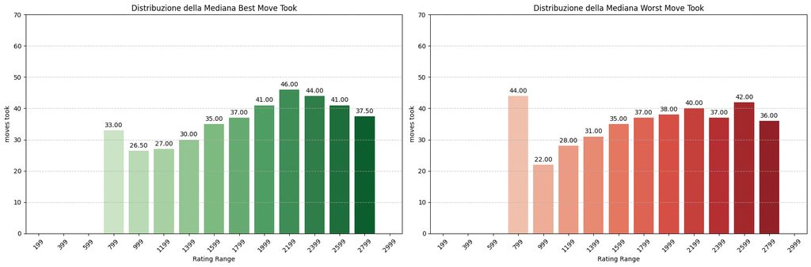

# Conclusioni

### Risultati Principali

Il progetto ha dimostrato che:

1. **Esiste una correlazione** tra il rating dei giocatori e il momento in cui effettuano mosse critiche
2. I giocatori di **livello superiore** mantengono prestazioni costanti per periodi più lunghi
3. La **distribuzione temporale** delle mosse critiche può essere un indicatore del livello di abilità

[Dataset:](https://www.kaggle.com/datasets/ulrikthygepedersen/online-chess-games?select=chess_games.csv)